# Read and visualize Anemone occurrence data

Damiano Oldoni

Coauthor A

Coauthor B

2024-12-18

# 1 Introduction

In this document we will:

1. read occurrence cube data
2. explore data
3. preprocess data
4. visualize data

# 2 Read and preprocess

Load packages:

```r
library(tidyverse)    # to do datascience
library(INBOtheme)    # to apply INBO style to graphs
library(sf)           # to work with geospatial vector data
library(mapview)      # to make dynamic leaflet maps
```

## 2.1 Read data

Read *Anemone* data from the occurrence cube file `20241217_occurrence_cube_anemone.tsv`:

```r
anemone_cube <- readr::read_tsv(
  file = "./data/20241217/20241217_occurrence_cube_anemone.tsv",
  na = ""
)
```

Read the Belgian grid from the geopackage file `20241217_utm1_be.gpkg`, derived from the shapefile as provided by the [European Environment Agency](https://www.eea.europa.eu/en):

```r
be_grid <- sf::st_read("./data/20241217/20241217_utm1_be.gpkg")
```

## 2.2 Explore data

This dataset contain data from 2010 to 2023 related to 4 species and their distribution in Belgium based on a grid of 1 km x 1 km.

Preview with the first 30 rows of the dataset:

```r
head(anemone_cube, n = 30)
```

| year | eeacellcode | classkey | class | specieskey | species | occurrences | mincoordinateuncertaintyinmeters | mintemporaluncertainty | classcount |
| --- | --- | --- | --- | --- | --- | --- | --- | --- | --- |
| 2023 | 1kmE3802N3109 | 220 | Magnoliopsida | 3033242 | Anemone blanda | 1 | 9 | 86400 | 1440830 |
| 2023 | 1kmE3813N3140 | 220 | Magnoliopsida | 3033242 | Anemone blanda | 3 | 14 | 86400 | 1440830 |
| 2023 | 1kmE3821N3106 | 220 | Magnoliopsida | 3033242 | Anemone blanda | 4 | 3 | 86400 | 1440830 |
| 2023 | 1kmE3840N3120 | 220 | Magnoliopsida | 3033242 | Anemone blanda | 1 | 7 | 86400 | 1440830 |
| 2023 | 1kmE3842N3131 | 220 | Magnoliopsida | 3033242 | Anemone blanda | 1 | 9 | 86400 | 1440830 |
| 2023 | 1kmE3845N3157 | 220 | Magnoliopsida | 3033242 | Anemone blanda | 1 | 4 | 86400 | 1440830 |
| 2023 | 1kmE3846N3157 | 220 | Magnoliopsida | 3033242 | Anemone blanda | 3 | 3 | 86400 | 1440830 |
| 2023 | 1kmE3854N3102 | 220 | Magnoliopsida | 3033242 | Anemone blanda | 1 | 4 | 86400 | 1440830 |
| 2023 | 1kmE3863N3128 | 220 | Magnoliopsida | 3033242 | Anemone blanda | 1 | 8 | 86400 | 1440830 |
| 2023 | 1kmE3871N3103 | 220 | Magnoliopsida | 3033242 | Anemone blanda | 1 | 8 | 86400 | 1440830 |

[output cut: 20 more lines]

## 2.3 Taxonomic information

Species present in the dataset:

```r
anemone_cube %>% distinct(specieskey, species)
```

| specieskey | species |
| --- | --- |
| 3033242 | Anemone blanda |
| 3033261 | Anemone coronaria |
| 3927746 | Anemone apennina |
| 3922888 | Anemone sylvestris |

## 2.4 Temporal information

The data are temporally defined at year level. Years present:

```r
anemone_cube %>% dplyr::distinct(year)
```

| year |
| --- |
| 2023 |
| 2022 |
| 2021 |
| 2020 |
| 2019 |
| 2018 |
| 2017 |
| 2016 |
| 2015 |
| 2014 |

[output cut: 4 more lines]

## 2.5 Geographical information

The geographical information is represented by the `eeacellcode` column, which contains the identifiers of the grid cells containing at least one occurrence of the species.

The dataset contains 367 unique grid cells.

## 2.6 Preprocess data

Add geometrical information to the occurrence cube via `eeacellcode`, which contains the identifiers of the grid cells containing at least one occurrence of the species.

```r
cells_in_cube <- be_grid %>%
  dplyr::filter(CELLCODE %in% unique(anemone_cube$eeacellcode)) %>%
  dplyr::select(-c(EOFORIGIN, NOFORIGIN))
sf_anemone_cube <- cells_in_cube %>%
  dplyr::left_join(anemone_cube, by = c("CELLCODE" = "eeacellcode")) %>%
  dplyr::rename("eeacellcode" = "CELLCODE")
```

Final (spatial) dataset:

```r
sf_anemone_cube %>% head(n = 30)
```

|  | eeacellcode | year | classkey | class | specieskey | species | occurrences | mincoordinateuncertaintyinmeters | mintemporaluncertainty | classcount | geom |
| --- | --- | --- | --- | --- | --- | --- | --- | --- | --- | --- | --- |
| 1 | 1kmE3802N3109 | 2023 | 220 | Magnoliopsida | 3033242 | Anemone blanda | 1 | 9 | 86400 | 1440830 |  |
| 2 | 1kmE3802N3109 | 2022 | 220 | Magnoliopsida | 3033242 | Anemone blanda | 1 | 4 | 86400 | 1440830 |  |
| 3 | 1kmE3802N3134 | 2019 | 220 | Magnoliopsida | 3033242 | Anemone blanda | 1 | 30 | 86400 | 1440830 |  |
| 4 | 1kmE3802N3135 | 2017 | 220 | Magnoliopsida | 3927746 | Anemone apennina | 2 | 10 | 86400 | 1440830 |  |
| 5 | 1kmE3803N3135 | 2021 | 220 | Magnoliopsida | 3927746 | Anemone apennina | 1 | 5 | 86400 | 1440830 |  |
| 6 | 1kmE3804N3135 | 2016 | 220 | Magnoliopsida | 3033242 | Anemone blanda | 4 | 10 | 86400 | 1440830 |  |
| 7 | 1kmE3806N3138 | 2021 | 220 | Magnoliopsida | 3033261 | Anemone coronaria | 1 | 25 | 86400 | 1440830 |  |
| 8 | 1kmE3807N3131 | 2020 | 220 | Magnoliopsida | 3033242 | Anemone blanda | 1 | 15 | 86400 | 1440830 |  |
| 9 | 1kmE3808N3108 | 2021 | 220 | Magnoliopsida | 3033242 | Anemone blanda | 3 | 5 | 86400 | 1440830 |  |
| 10 | 1kmE3808N3137 | 2020 | 220 | Magnoliopsida | 3033242 | Anemone blanda | 1 | 25 | 86400 | 1440830 |  |

[output cut: 20 more lines]

# 3 Data visualization

In this section we will show how the number of occurrences and the number of occupied grid cells vary by year and species. Both static plots and dynamic maps are generated.

## 3.1 Static plots

Show number of occurrences and number of occupied grid cells (make a tabbed section out of it)

### 3.1.1 per species

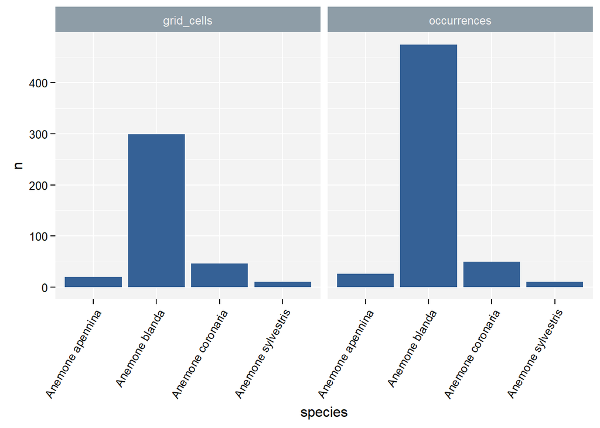

```r
n_per_species <- sf_anemone_cube %>%
  dplyr::group_by(species) %>%
  dplyr::summarize(occurrences = sum(occurrences),
                   grid_cells = n_distinct(eeacellcode),
                   .groups = "drop") %>%
  tidyr::pivot_longer(cols = c(occurrences, grid_cells),
                      names_to = "variable",
                      values_to = "n")

ggplot(n_per_species, aes(x = species, y = n)) +
  geom_bar(stat = 'identity') +
  facet_grid(.~variable, scales = "free_y") +
  ggplot2::theme(axis.text.x = element_text(angle = 60, hjust = 1))
```

### 3.1.2 per year

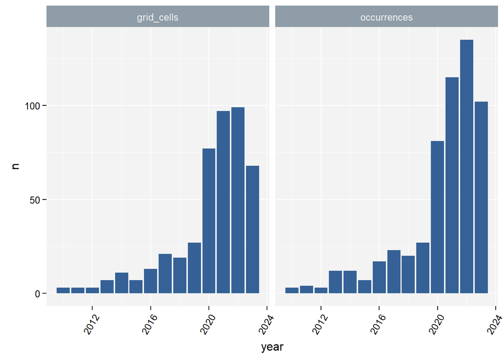

```r
n_per_year <- sf_anemone_cube %>%
  dplyr::group_by(year) %>%
  dplyr::summarize(occurrences = sum(occurrences),
                   grid_cells = n_distinct(eeacellcode),
                   .groups = "drop") %>%
  tidyr::pivot_longer(cols = c(occurrences, grid_cells),
                      names_to = "variable",
                      values_to = "n")

ggplot(n_per_year,aes(x = year, y = n)) +
  geom_bar(stat = 'identity') +
  facet_grid(.~variable, scales = "free_y") +
  ggplot2::theme(axis.text.x = element_text(angle = 60, hjust = 1))
```

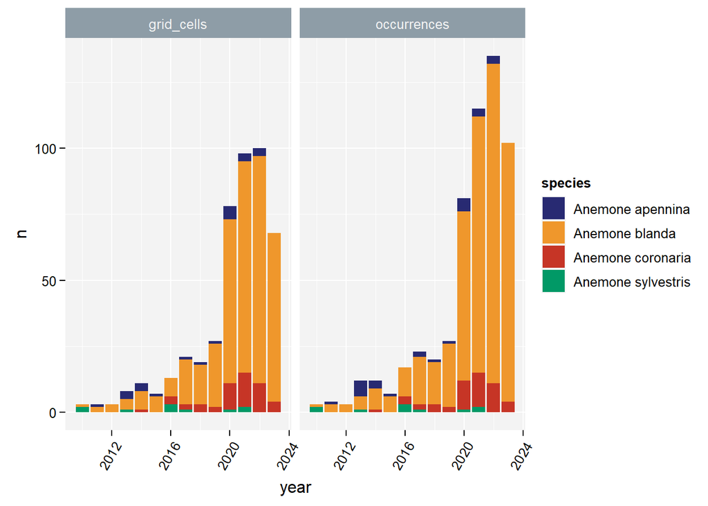

```r
n_occs_per_year_species <-
  sf_anemone_cube %>%
  dplyr::group_by(year, species) %>%
  dplyr::summarize(occurrences = sum(occurrences),
                   grid_cells = n_distinct(eeacellcode),
                   .groups = "drop") %>%
  tidyr::pivot_longer(cols = c(occurrences, grid_cells),
                      names_to = "variable",
                      values_to = "n")

ggplot(n_occs_per_year_species,
       aes(x = year, y = n, fill = species)) +
  geom_bar(stat = 'identity', scales = "free_y") +
  facet_grid(.~variable) +
  ggplot2::theme(axis.text.x = element_text(angle = 60, hjust = 1))
```

## 3.2 Dynamic maps

### 3.2.1 Leaflet maps

We show a map with the distribution of *Anemone* in Belgium. We show the total number of occurrences per grid cell. The color of the grid cells is based on the number of occurrences. The legend shows the color scale and the number of occurrences per grid cell.

```r
n_occs_per_cell <- sf_anemone_cube %>%
  dplyr::group_by(eeacellcode) %>%
  dplyr::summarize(
    occurrences = sum(occurrences),
    min_coordinateuncertaintyinmeters = min(mincoordinateuncertaintyinmeters),
    min_mintemporaluncertainty = min(mintemporaluncertainty),
    .groups = "drop")
map_anemone <- mapview::mapview(n_occs_per_cell,
                                zcol = "occurrences",
                                legend = TRUE
)
map_anemone
```

[interactive chart not shown]

# 4 Notes

Extra information came out during the INBO coding club have been added here below.

## 4.1 Date of the document

If you want to set a fix date for the document, please replace the 2024-12-18 in the YAML header with the desired date in the format `YYYY-MM-DD`. For example, `date: "2024-12-17"`.

## 4.2 `reveal.js`

Presentations in RMarkdown via `reveal.js`:

- https://bookdown.org/yihui/rmarkdown/revealjs.html
- https://github.com/rstudio/revealjs

reveal.js is an html presentation framework; RStudio/RMarkdown (as many other programming environments) have convenience functions to export to a reveal.js presentation. Because your presentation will essentially be *html*, it is versatile with media content and animation. For example, you can embed YouTube videos or interactive maps.

Info on reveal.js (with example) at https://revealjs.com.

There is an impressive demo included at https://quarto.org/docs/presentations/revealjs.

## 4.3 Convert a `.R` script to a `.Rmd`: stitching

You can convert an R script to an Rmd file: it’s called *stitching*. Use the `stitch()` function from the `knitr` package.

Example:

```r
library("knitr")
knitr::stitch("src/20241217/20241217_challenges.R")
```

More info at https://yihui.org/knitr/demo/stitch/.

## 4.4 Convert a `.Rmd` to a `.R` script: purling

The opposite of stitching is called *purling*. You can do it via the `purl()` function from `knitr` package: https://bookdown.org/yihui/rmarkdown-cookbook/purl.html

This enables a good workflow to produce well-documented R scripts: write an Rmd, `purl` it to a `.R` file. All the supporting text will become comments in the R script. Handy if you need to share your code with someone who doesn’t use RMarkdown or a machine which has to execute automatically some code (workflow automatisation).

## 4.5 References and citation in RMarkdown

Do you know Hans Van Calster wrote a wonderful tutorial about how to cite in RMarkdown? It’s available at https://tutorials.inbo.be/tutorials/r_citations_markdown.

Other documentation can be found at:

- https://bookdown.org/yihui/rmarkdown-cookbook/bibliography.html
- https://docs.citationstyles.org/en/stable/primer.html

## 4.6 Caching

If a chunk takes a long time to run, you can cache the results. This means that the chunk will only be run once, and the results will be saved. The next time you knit the document, the results will be loaded from the cache. This can save a lot of time when you are working on a document.

Example:

````r
# ```{r, cache=TRUE}
# code that takes a long time to run
# ```
````